# ACTIVITAT A3-2 ESTADÍSTICA

Gabriel Guardiola (individual)

29/12/2021

**Estadística descriptiva**

### Ejercicio 1

Importa el archivo “plantilla.csv” Haz la FA (frecuencia absoluta) y la FR (frecuencia relativa) de las variables “Edad” y “Sueldo”

**Información adicional sobre el csv:**  
Es la plantilla de una empresa donde consta el nombre, edad, sueldo (en euros), y años de antiguedad. El sueldo no tiene porqué ser directamente propocional a su antiguedad, ya que cada uno ocupa diferentes puestos y responsabilidades.

```r
plantilla = read.csv("plantilla.csv", sep=";");
plantilla
```

```
##       Nombre Edad Sueldo Antiguedad
## 1       Pepe   19   1300          1
## 2       Juan   22   1400          1
## 3       Maya   27   1600          2
## 4       Fran   30   2500          4
## 5     Manolo   20   1100          1
## 6  Estefania   26   1600          2
## 7    Gabriel   27   2000          3
## 8      Tania   18   1200          1
## 9    Roberto   40   2600          5
## 10    Samuel   35   2500          5
## 11      Igor   27   2100          3
## 12   Eugenio   21   1200          1
## 13   Mariona   19   1200          1
## 14  Fernando   37   2300          4
## 15     Tomas   26   1600          2
## 16     Joana   21   1100          1
## 17       Ana   21   1800          2
## 18      Ivan   36   2600          5
```

FA de “Edad”:

```r
edadT = table(plantilla$Edad);#FA
edadT
```

```
##
## 18 19 20 21 22 26 27 30 35 36 37 40
##  1  2  1  3  1  2  3  1  1  1  1  1
```

FR de “Edad”:

```r
edadP = prop.table(edadT);##FR
edadP
```

```
##
##         18         19         20         21         22         26         27
## 0.05555556 0.11111111 0.05555556 0.16666667 0.05555556 0.11111111 0.16666667
##         30         35         36         37         40
## 0.05555556 0.05555556 0.05555556 0.05555556 0.05555556
```

FA de “Sueldo”:

```r
sueldoT = table(plantilla$Sueldo);#FA
sueldoT
```

```
##
## 1100 1200 1300 1400 1600 1800 2000 2100 2300 2500 2600
##    2    3    1    1    3    1    1    1    1    2    2
```

FR de “Sueldo”:

```r
sueldoP = prop.table(sueldoT);#FR
sueldoP
```

```
##
##       1100       1200       1300       1400       1600       1800       2000
## 0.11111111 0.16666667 0.05555556 0.05555556 0.16666667 0.05555556 0.05555556
##       2100       2300       2500       2600
## 0.05555556 0.05555556 0.11111111 0.11111111
```

Muestra el Nombre de las personas menores de 20 años

```r
menores = plantilla$Nombre[plantilla$Edad<20]
menores
```

```
## [1] "Pepe"    "Tania"   "Mariona"
```

Añade al DataFrame una variable nueva de tipo Factor que se llame “Categoria” y que recodifique “antiguedad” según el siguiente codigo:  
Freshman (si tiene 1 año de antiguedad)  
Sophomore (si tiene 2 años de antiguedad)  
Junior (si tiene 3 años de antiguedad)  
Senior (si tiene 4 años o MÁS de antiguedad)

```r
plantilla$Categoria[plantilla$Antiguedad==1] = "Freshman"
plantilla$Categoria[plantilla$Antiguedad==2] = "Sophomore"
plantilla$Categoria[plantilla$Antiguedad==3] = "Junior"
plantilla$Categoria[plantilla$Antiguedad>=4] = "Senior"

plantilla
```

```
##       Nombre Edad Sueldo Antiguedad Categoria
## 1       Pepe   19   1300          1  Freshman
## 2       Juan   22   1400          1  Freshman
## 3       Maya   27   1600          2 Sophomore
## 4       Fran   30   2500          4    Senior
## 5     Manolo   20   1100          1  Freshman
## 6  Estefania   26   1600          2 Sophomore
## 7    Gabriel   27   2000          3    Junior
## 8      Tania   18   1200          1  Freshman
## 9    Roberto   40   2600          5    Senior
## 10    Samuel   35   2500          5    Senior
## 11      Igor   27   2100          3    Junior
## 12   Eugenio   21   1200          1  Freshman
## 13   Mariona   19   1200          1  Freshman
## 14  Fernando   37   2300          4    Senior
## 15     Tomas   26   1600          2 Sophomore
## 16     Joana   21   1100          1  Freshman
## 17       Ana   21   1800          2 Sophomore
## 18      Ivan   36   2600          5    Senior
```

Representa en un gráfico de barras la variable Categoria.

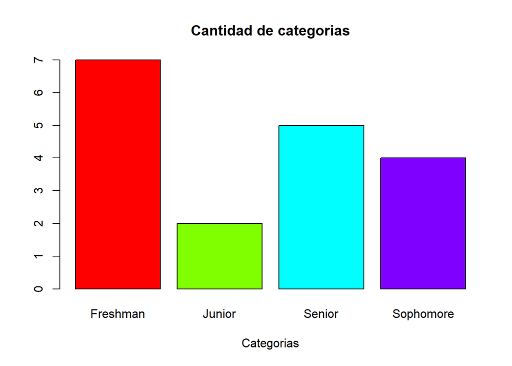

```r
barplot(table(plantilla$Categoria),col=rainbow(4),xlab="Categorias",main="Cantidad de categorias")
```

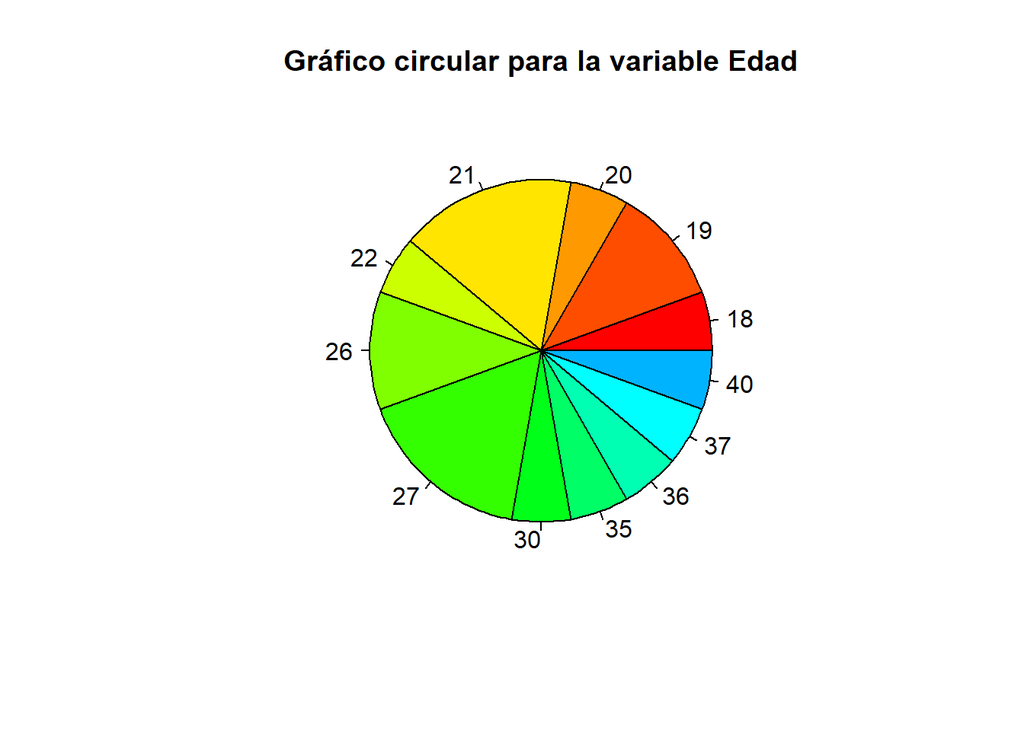

```r
pie(table(plantilla$Edad),col=rainbow(20), main = "Gráfico circular para la variable Edad")
```

**OBSERVACIÓN:** podemos observar que la mayoria de personas tienen 21 y 27 años.  
Representa en un histograma, la variable Sueldos

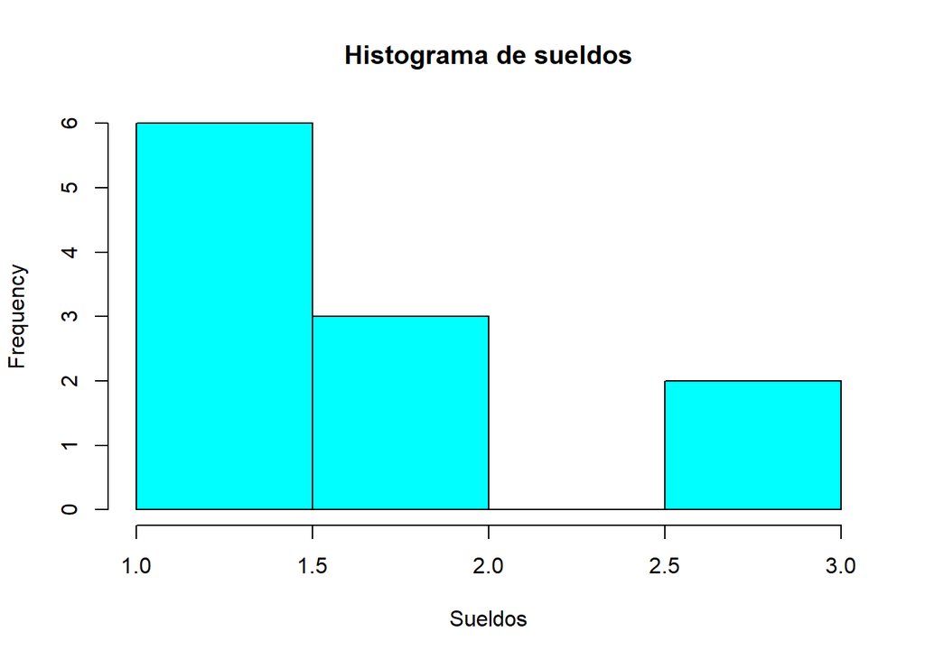

```r
hist(table(plantilla$Sueldo), col = "cyan", main = "Histograma de sueldos", xlab="Sueldos")
```

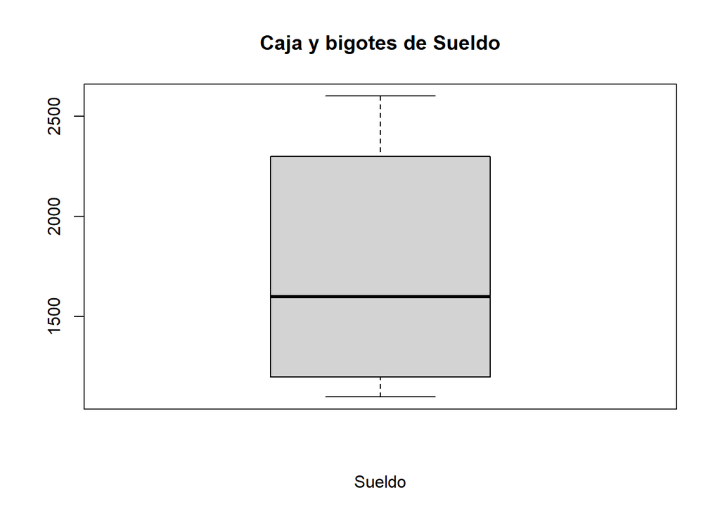

```r
boxplot(plantilla$Sueldo,xlab="Sueldo",main="Caja y bigotes de Sueldo")
```

```r
mean(plantilla$Edad)
```

```
## [1] 26.22222
```

```r
median(plantilla$Edad)
```

```
## [1] 26
```

```r
mean(plantilla$Sueldo)
```

```
## [1] 1761.111
```

```r
median(plantilla$Sueldo)
```

```
## [1] 1600
```

Muestra el summary de Sueldo.

```r
summary(plantilla$Sueldo)
```

```
##    Min. 1st Qu.  Median    Mean 3rd Qu.    Max.
##    1100    1225    1600    1761    2250    2600
```

Muestra los quantils de la variable Sueldo.

```r
quantile(plantilla$Sueldo)
```

```
##   0%  25%  50%  75% 100%
## 1100 1225 1600 2250 2600
```

Muestra la desviación estandar, el rango intercuartilico y la variancia de la variable Sueldo.

```r
variancia = var(plantilla$Sueldo)
variancia
```

```
## [1] 306045.8
```

```r
desviacio = sd(plantilla$Sueldo)
desviacio
```

```
## [1] 553.214
```

```r
rangI = IQR(plantilla$Sueldo)
rangI
```

```
## [1] 1025
```

Muestra el porcentaje de la variable Antiguedad y redondea a 2 decimales.

```r
total = round(prop.table(table(plantilla$Antiguedad))*100,digits=2)
total
```

```
##
##     1     2     3     4     5
## 38.89 22.22 11.11 11.11 16.67
```

Muestra las edades ordenadas.

```r
sort(plantilla$Edad)
```

```
##  [1] 18 19 19 20 21 21 21 22 26 26 27 27 27 30 35 36 37 40
```

**Inferencia estadística**

### Ejercicio 2

De una tienda de coches de segunda mano, queremos encontrar el intérvalo de confianza para un nivel del 95%. La tienda consta de una muestra de 150 coches, con un valor medio de 1200. Se conoce por su historial de coches vendidos que la desviación típica es de 10.

```r
alfa = 0.05
qn = qnorm(1-alfa/2)
n = 150
var = 10^2
med = 1200
inter1 = med-qn*(var)/sqrt(n)
inter2 = med+qn*(var)/sqrt(n)
sprintf("[%s , %s]",inter1,inter2)
```

```
## [1] "[1183.99696107882 , 1216.00303892118]"
```

### Ejercicio 3

Según una muestra de 25 personas donde se mide la cantidad de minutos que han tardado en ser atendidos para hacerse un test PCR, determina la media y el intérvalo de confianza al nivel 98%

```r
muestra = read.csv("ej3.csv", sep=";");
muestra
```

```
##    Minutos.en.espera
## 1                  5
## 2                 10
## 3                  3
## 4                  4
## 5                  4
## 6                  9
## 7                  8
## 8                  1
## 9                  5
## 10                12
## 11                 5
## 12                17
## 13                13
## 14                10
## 15                 9
## 16                 5
## 17                 3
## 18                 1
## 19                18
## 20                10
## 21                 4
## 22                20
## 23                 7
## 24                11
## 25                12
```

Media de minutos en ser atendidos:

```r
medi = mean(muestra$Minutos.en.espera)
medi
```

```
## [1] 8.24
```

IC al 98%:

```r
alfa = 0.02
desvi = sd(muestra$Minutos.en.espera)
qt = qt((1-alfa/2),24,lower.tail = T)

inter1 = medi-qt*(desvi)/sqrt(length(muestra$Minutos.en.espera))
inter2 = medi+qt*(desvi)/sqrt(length(muestra$Minutos.en.espera))
sprintf("[%s , %s]",inter1,inter2)
```

```
## [1] "[5.6730354167592 , 10.8069645832408]"
```

En conclusión, en el intérvalo **[5.6730354167592 , 10.8069645832408]** hay un 98% de confianza.  
Gráfico circular de los minutos de espera:

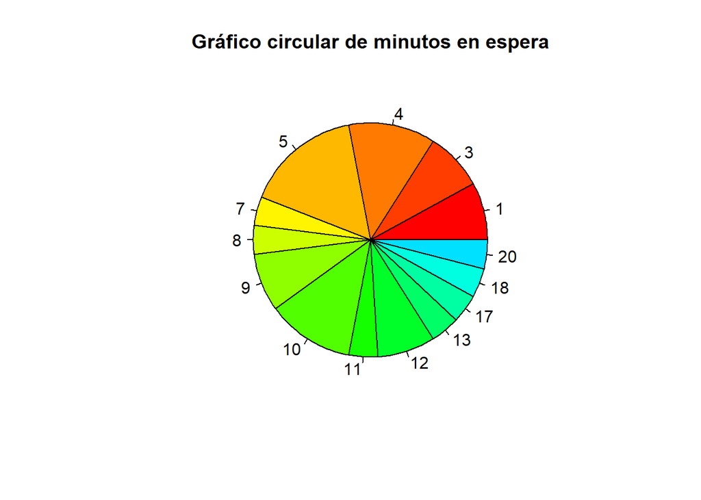

```r
pie(table(muestra$Minutos.en.espera),col=rainbow(25), main = "Gráfico circular de minutos en espera")
```

**OBSERVACIÓN:** podemos observar que la mayoria de personas han esperado 5 minutos.

Otra forma más sencilla y directa de hacerlo:

```r
t.test(muestra$Minutos.en.espera,conf.level = 0.98)
```

```
##
##  One Sample t-test
##
## data:  muestra$Minutos.en.espera
## t = 7.9999, df = 24, p-value = 3.157e-08
## alternative hypothesis: true mean is not equal to 0
## 98 percent confidence interval:
##   5.673035 10.806965
## sample estimates:
## mean of x
##      8.24
```

### Problema 4 - ANOVA

En una empresa de paquetería hay 5 básculas y para optimizar el ritmo de trabajo se necesita que las 5 básculas hayan pesado una cantidad similar entre ellas al acabar el día. Por la bascula 1 han pasado 52 paquetes, por la bascula 2, 31, por la bascula 3, 45, por la bascula 4, 52, y por la bascula 5, 27.  
Omite los valores vacios “NA” y guarda cada columna en una variable.

```r
datos = read.csv("pesos.csv",stringsAsFactors = T)
b1 = na.omit(datos$Bascula1)
b2 = na.omit(datos$Bascula2)
b3 = na.omit(datos$Bascula3)
b4 = na.omit(datos$Bascula4)
b5 = na.omit(datos$Bascula5)
```

Genera un gráfico de caja y bigotes para analizar previamente cada báscula.

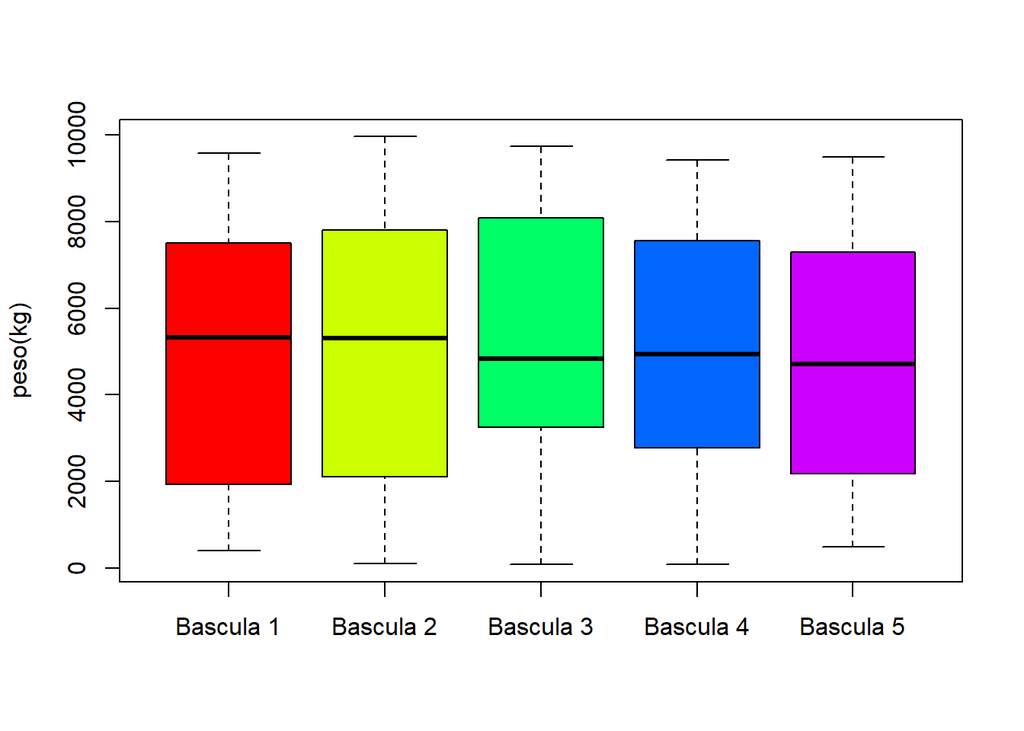

```r
boxplot(b1,b2,b3,b4,b5,ylab="peso(kg)",col=rainbow(5),names=c("Bascula 1","Bascula 2","Bascula 3","Bascula 4","Bascula 5"))
```

**OBSERVACIÓN:** podemos destacar que: la Bascula 3 es la que más objetos pesados a registrado, mientras que la Bascula 1 ha sido la que más objetos ligeros ha registrado. La media de todas las básculas oscila entre 4500kg y 5700kg (aproximadamente).  
Calcula los grados de libertat y las medianas.

```r
m = 5
n1 = length(b1)
n2 = length(b2)
n3 = length(b3)
n4 = length(b4)
n5 = length(b5)
n = n1+n2+n3+n4+n5
n
```

```
## [1] 207
```

```r
mb1 = mean(b1)
mb2 = mean(b2)
mb3 = mean(b3)
mb4 = mean(b4)
mb5 = mean(b5)
totalm=1/n*(sum(b1)+sum(b2)+sum(b3)+sum(b4)+sum(b5))
sprintf("Mediana total: %s",(totalm))
```

```
## [1] "Mediana total: 5006.44444444444"
```

Calcula la suma de cuadrados.

```r
VT = sum((b1-totalm)^2)+sum((b2-totalm)^2)+sum((b3-totalm)^2)+sum((b4-totalm)^2)+sum((b5-totalm)^2)
VR = sum((b1-mb1)^2)+sum((b2-mb2)^2)+sum((b3-mb3)^2)+sum((b4-mb4)^2)+sum((b5-mb5)^2)
VE = n1*(mb1-totalm)^2+n2*(mb2-totalm)^2+n3*(mb3-totalm)^2+n4*(mb4-totalm)^2+n5*(mb5-totalm)^2
```

Calcula las variancias.

```r
sT2 = VT/(n-1)
sR2 = VR/(n-m)
sE2 = VE/(m-1)
```

Calcula l’estadistic mostral.

```r
z = sE2/sR2
```

Tabla ANOVA:

```r
anovaDF = data.frame(
  SS = c(VE,VR,VT),
  DF = c((m-1),(n-m),(n-1)),
  S2 = c(sE2,sR2,sT2),
  Z = c(NA,NA,z)
)
anovaDF
```

```
##           SS  DF      S2         Z
## 1   12291517   4 3072879        NA
## 2 1772201148 202 8773273        NA
## 3 1784492665 206 8662586 0.3502546
```

Calcula la RR con un nivel de confianza del 95%.

```r
alfa = 0.05
Za = qf(1-alfa,m-1,n-m)
RR = sprintf("RR = (%s, +inf)",Za)
print(RR)
```

```
## [1] "RR = (2.41635088598958, +inf)"
```

**Cómo Z < RR, se acepta la hipotesis.**